# Week 8 random forest on mortgage dataset

## Mortgage default detection in imbalanced dataset with random forest model

### Author: Huizhe (Sunny) ZHU - hz2657

**Background**

The goal of this project is to identify candidates that are most likely to default, by building bagging/random forest model from H2O open source. Our dataset is the 'loan default' dataset which contains 80000 applicants' information and whether they default or not. Only 19% cases are default cases, thus the dataset is imbalanced.

**Deal with imbalanced data**

Data imbalance can reduce model performance and increase the number of false negatives. To make the dataset more balanced, We will use data sampling techniques such as under-sampling and over-sampling methods to handle this imbalanced dataset.

1) undersampling techniques: take samples from majority since they contain same info

2) Oversampling: bootstrap for miniority

To evaluete model performance for imbalanced data, we will use precision recall curve besides the traditional AUC/ROC method, since AUC does not place emphasis on imbalanced dataset. Precision-Recall (PR) curves is more informative, and the area under precision-recall curve is more sensitive than the area under ROC curve, because precision (TP/TP+FP) is directly influenced by imbalanced dataset.

**Notebook structure**

1. Load and explore data
2. Feature selection
3. EDA on selected features
4. Data sampling
5. Fit model, prediction, and model evaluation: ROC, precision recall curve, gains table, the cumulative Lift
6. Summary and busienss insights

## 1. Load and explore data

- Load, clean data, match column names and description

```python
# import dataset, the first 3 columns do not contain valid info, we will remove these them later
import numpy as np
import pandas as pd
df = pd.read_csv('XYZloan_default_selected_vars.csv')
df.head(3)
```

|  | Unnamed: 0 | Unnamed: 0.1 | id | loan_default | AP001 | AP002 | AP003 | AP004 | AP005 | AP006 | ... | CD162 | CD164 | CD166 | CD167 | CD169 | CD170 | CD172 | CD173 | MB005 | MB007 |
| --- | --- | --- | --- | --- | --- | --- | --- | --- | --- | --- | --- | --- | --- | --- | --- | --- | --- | --- | --- | --- | --- |
| 0 | 0 | 1 | 1 | 1 | 31 | 2 | 1 | 12 | 2017/7/6 10:21 | ios | ... | 13.0 | 13.0 | 0.0 | 0.0 | 1449.0 | 1449.0 | 2249.0 | 2249.0 | 7.0 | IPHONE7 |
| 1 | 1 | 2 | 2 | 0 | 27 | 1 | 1 | 12 | 2017/4/6 12:51 | h5 | ... | -99.0 | -99.0 | -99.0 | -99.0 | -99.0 | -99.0 | -99.0 | -99.0 | NaN | WEB |
| 2 | 2 | 3 | 3 | 0 | 33 | 1 | 4 | 12 | 2017/7/1 14:11 | h5 | ... | 3.0 | 2.0 | 33.0 | 0.0 | 33.0 | 0.0 | 143.0 | 110.0 | 8.0 | WEB |

3 rows × 89 columns

```python
# the dataset has 80,000 rows and 89 columns
df.shape
```

```
(80000, 89)
```

the dataset has 19.3% default, indicates the dataset is imbalanced.

```python
# examine number of rows and columns for the dataset: 19% default in total records
df['loan_default'].value_counts()/df['loan_default'].count()
```

```
0    0.8064
1    0.1936
Name: loan_default, dtype: float64
```

```python
# explore column name: 85 independent variables after excluding the first 3 columns
# however, the names do not contain meanings directly, we need to connect with another data source to make sense of the column names in next step
columns_names = df.columns
columns_names[4:]
```

```
Index(['AP001', 'AP002', 'AP003', 'AP004', 'AP005', 'AP006', 'AP007', 'AP008',
       'AP009', 'TD001', 'TD002', 'TD005', 'TD006', 'TD009', 'TD010', 'TD013',
       'TD014', 'TD015', 'TD022', 'TD023', 'TD024', 'TD025', 'TD026', 'TD027',
       'TD028', 'TD029', 'TD044', 'TD048', 'TD051', 'TD054', 'TD055', 'TD061',
       'TD062', 'CR004', 'CR005', 'CR009', 'CR012', 'CR015', 'CR017', 'CR018',
       'CR019', 'PA022', 'PA023', 'PA028', 'PA029', 'PA030', 'PA031', 'CD008',
       'CD018', 'CD071', 'CD072', 'CD088', 'CD100', 'CD101', 'CD106', 'CD107',
       'CD108', 'CD113', 'CD114', 'CD115', 'CD117', 'CD118', 'CD120', 'CD121',
       'CD123', 'CD130', 'CD131', 'CD132', 'CD133', 'CD135', 'CD136', 'CD137',
       'CD152', 'CD153', 'CD160', 'CD162', 'CD164', 'CD166', 'CD167', 'CD169',
       'CD170', 'CD172', 'CD173', 'MB005', 'MB007'],
      dtype='object')
```

### Match column names and description

```python
# load another data source which contains column names' details
Variables_Dictionary = pd.read_excel('Variables_Dictionary_2019.xlsx')
```

```python
# extract meaningful information
Variables_Dictionary = Variables_Dictionary.loc[3:,]
Variables_Dictionary=Variables_Dictionary.drop(columns=['Unnamed: 0', 'Unnamed: 1','Unnamed: 3','Unnamed: 5'])
Variables_Dictionary.columns = ['var', 'description']
```

```python
# create reference table contains descriptions for the variables in dataset
# from the table below we can examine columns meanings
Variables_Dictionary=Variables_Dictionary[Variables_Dictionary['var'].isin(columns_names[4:])]
Variables_Dictionary
```

|  | var | description |
| --- | --- | --- |
| 3 | AP001 | YR_AGE |
| 4 | AP002 | CODE_GENDER |
| 5 | AP003 | CODE_EDUCATION |
| 6 | AP004 | LOAN_TERM |
| 7 | AP005 | DATE_APPLIED |
| ... | ... | ... |
| 254 | PA023 | DAYS_BTW_APPLICATION_AND_FIRST_COLLECTION_CALL |
| 259 | PA028 | AVG_LEN_COLLECTION_OR_HIGH_RISK_CALLS |
| 260 | PA029 | AVG_LEN_COLLECTION_OR_HIGH_RISK_INBOUND_CALLS |
| 261 | PA030 | AVG_LEN_COLLECTION_OR_HIGH_RISK_OUTBOUND_CALLS |
| 262 | PA031 | AVG_LEN_COLLECTION_CALLS |

68 rows × 2 columns

## 2. Feature selection

The dataset has 85 variables, before building the model, we perform variable selection first.

```python
# drop first three columns which do not have valuable information, save it as df1
df1=df
df1 = df1.drop(columns=['Unnamed: 0', 'Unnamed: 0.1','id'])
```

### 2.1 Examine missing values

- From the table below, we can check the number of missing values for each column
- For variables 'TD044', 'TD048','TD051','TD054','TD055','TD061','TD062', they have more than 79990 missing values and no variable description, we have 80000 rows in our dataset, in this case, we will drop these variables

```python
# set display max rows = 999
pd.options.display.max_rows = 999

# examine missing value: more than half variables have missing values
na_summary = df1.isnull().sum()
na_summary = pd.DataFrame(data=na_summary)
na_summary['var'] = na_summary.index   # reset index
na_summary.columns = ['num_missing_values','var']

# merge with Variables_Dictionary table
pd.merge(na_summary, Variables_Dictionary, how='left', on='var')
```

|  | num_missing_values | var | description |
| --- | --- | --- | --- |
| 0 | 0 | loan_default | NaN |
| 1 | 0 | AP001 | YR_AGE |
| 2 | 0 | AP002 | CODE_GENDER |
| 3 | 0 | AP003 | CODE_EDUCATION |
| 4 | 0 | AP004 | LOAN_TERM |
| 5 | 0 | AP005 | DATE_APPLIED |
| 6 | 0 | AP006 | OS_TYPE |
| 7 | 0 | AP007 | LEVEL_APPL_CITY |
| 8 | 0 | AP008 | FLAG_IP_CITY_NOT_APPL_CITY |
| 9 | 0 | AP009 | NaN |
| 10 | 0 | TD001 | TD_CNT_QUERY_LAST_7Day_P2P |
| 11 | 0 | TD002 | TD_CNT_QUERY_LAST_7Day_SMALL_LOAN |
| 12 | 0 | TD005 | TD_CNT_QUERY_LAST_1MON_P2P |
| 13 | 0 | TD006 | TD_CNT_QUERY_LAST_1MON_SMALL_LOAN |
| 14 | 0 | TD009 | TD_CNT_QUERY_LAST_3MON_P2P |
| 15 | 0 | TD010 | TD_CNT_QUERY_LAST_3MON_SMALL_LOAN |
| 16 | 0 | TD013 | TD_CNT_QUERY_LAST_6MON_P2P |
| 17 | 0 | TD014 | TD_CNT_QUERY_LAST_6MON_SMALL_LOAN |
| 18 | 0 | TD015 | TD_CNT_QUERY_LAST_6MON_BANK |
| 19 | 19598 | TD022 | NaN |
| 20 | 7663 | TD023 | NaN |
| 21 | 3694 | TD024 | NaN |
| 22 | 2550 | TD025 | NaN |
| 23 | 1846 | TD026 | NaN |
| 24 | 1697 | TD027 | NaN |
| 25 | 1636 | TD028 | NaN |
| 26 | 1630 | TD029 | NaN |
| 27 | 79997 | TD044 | NaN |
| 28 | 79999 | TD048 | NaN |
| 29 | 79995 | TD051 | NaN |

[output cut: 56 more lines]

```python
# drop variables that have more than 79990 missing values
df1 = df1.drop(columns=['TD044', 'TD048','TD051','TD054','TD055','TD061','TD062'])
# drop DATE_APPLIED
df1 = df1.drop(columns=['AP005'])
```

### 2.2 Use correlation matrix for feature selection

- Correlation states how the features are related to each other. We exclude variables which have more than 0.9 correlation with another variable.
- After this step, 56 columns left

```python
# get correlations of each features in dataset, it contains 83 rows
corr = df1.corr()

# drop AP006, MB007 from df1 because it is not contained in correlation matrix
df1 = df1.drop(columns=['AP006'])
df1 = df1.drop(columns=['MB007'])
```

```python
# remove one of two features that have a correlation higher than 0.9
columns = np.full((corr.shape[0],), True, dtype=bool)

for i in range(corr.shape[0]):
    for j in range(i+1, corr.shape[0]):
        if corr.iloc[i,j] >= 0.9:
            if columns[j]:
                columns[j] = False

selected_columns = df1.columns[columns]
df3 = df1[selected_columns]
```

```python
# add AP006,MB007 back in the new dataset df3
df3['AP006'] = df.loc[:,'AP006']
df3['MB007'] = df.loc[:,'MB007']
```

[output not shown]

```python
## check descriptions for what's left
# Variables_Dictionary[Variables_Dictionary['var'].isin(df3.columns)]
```

### 2.3 Use decision tree importance values for feature selection

In step 5, we found variables have the least importance and most importance, we will keep the following variables:

'TD009','TD013','TD005','TD014','PA028','CD115','TD024','AP004','PA031','AP003','CD131','MB005','CR004', 'TD010', 'CR015','PA022','CD018','CR005','CR009','CD152','PA029','TD023','AP002','CD160','CD169','CD130','TD001','CD166', 'CD088','CD008','CR017'

After this step, we have 30 varibles left.

```python
# only keep variables which have most importance in random forest model
df3 = df3.loc[:,['loan_default','TD009','TD013','TD005','TD014','PA028','CD115','TD024','AP004','PA031','AP003','AP006','CD131','MB005','CR004',
 'TD010', 'CR015','PA022','CD018','CR005','CR009','CD152','PA029','TD023','AP002','CD160','CD169','CD130','TD001','CD166',
 'CD008','CR017']]
```

## 3. EDA on selected features

```python
# to make sense of the columns, we combine column names from selected features with Variables_Dictionary dataset
Variables_Dictionary[Variables_Dictionary['var'].isin(df3.columns)].head(8)
```

[output not shown]

#### Select variables we want to explore:

- AP001: age
- AP002: gender
- AP003: education
- AP004: LOAN_TERM
- CR015: MONTH_CREDIT_CARD_MOB_MAX

```python
import seaborn as sns
import matplotlib.pyplot as plt
```

```
[Text(0.5, 0, 'age'), Text(0.5, 1.0, 'Distribution of Age')]
```

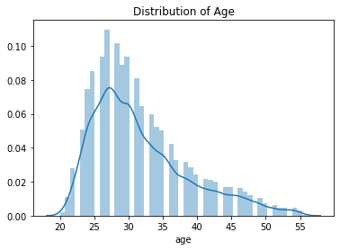

```python
# Distribution of Age
sns.distplot(df3['AP001']).set(xlabel='age', title = 'Distribution of Age')
```

```
[Text(0.5, 0, 'gender'), Text(0.5, 1.0, 'Distribution of gender')]
```

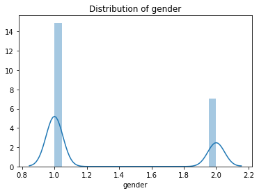

```python
# Distribution of gender: more 1 than 2
sns.distplot(df3['AP002']).set(xlabel='gender', title = 'Distribution of gender')
```

```
[Text(0.5, 0, 'education'), Text(0.5, 1.0, 'Distribution of education')]
```

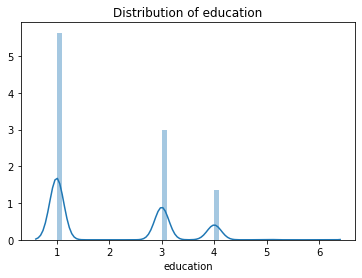

```python
# Distribution of education: more 1 than 3 and 4
sns.distplot(df3['AP003']).set(xlabel='education', title = 'Distribution of education')
```

```
[Text(0.5, 0, 'LOAN_TERM'), Text(0.5, 1.0, 'Distribution of LOAN_TERM')]
```

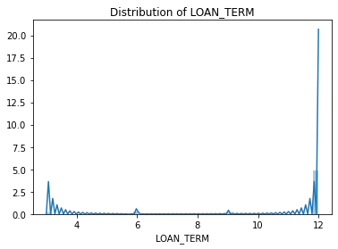

```python
# Distribution of LOAN_TERM: more 12-months term application
sns.distplot(df3['AP004']).set(xlabel='LOAN_TERM', title = 'Distribution of LOAN_TERM')
```

## 4. Apply data sampling techniques

Since the target variable is imbalanced, so we use sampling methods.

1) undersampling techniques: take samples from majority since they contain same info

2) Oversampling: bootstrap for miniority

### 4.0 prepare the data

```python
# get X, y
y = df3['loan_default']
X = df3.loc[:, df3.columns != 'loan_default']

# deal with missing values
X=X.fillna(X.mean())

# AP006 and MB007 are object, get dummies
X=pd.get_dummies(X, columns=['AP006'])
```

### 4.1 undersampling techniques

(1) Random undersampling: under-sample the majority class randomly and uniformly. This can potentially lead to loss of information. But if the examples of the majority class are near to others, this method might yield good results.

(2) Neighborhood Cleaning Rule (NCL) deals with the majority and minority samples separately when sampling the data sets. NCL uses ENN to remove majority examples. for each instance in the training set, it finds three nearest neighbors. If the instance belongs to the majority class and the classification given by its three nearest neighbors is the opposite of the class of the chosen instance, then the chosen instance is removed. If the chosen instance belongs to the minority class and is misclassified by its three nearest neighbors, then the nearest neighbors that belong to the majority class are removed.

```python
from imblearn.datasets import make_imbalance
from imblearn.under_sampling import (RandomUnderSampler,ClusterCentroids)
```

```python
# X has 80000 rows, 32 columns
X.shape
```

```
(80000, 34)
```

```python
# y is imbalanced, 15488 default, 64512 normal
y.value_counts()
```

[output not shown]

```python
# RandomUnderSampler: under sample 0 from 64512 to 20000, save results in X_rs, y_rs
sampler = RandomUnderSampler(ratio={1: 15488, 0: 20000})
X_rs, y_rs = sampler.fit_sample(X, y)
```

```python
# NeighbourhoodCleaningRule
from imblearn.under_sampling import NeighbourhoodCleaningRule
sampler = NeighbourhoodCleaningRule(ratio={1: 15488, 0: 20000},random_state=0)
X_rs_Neighbourhood, y_rs_Neighbourhood = sampler.fit_sample(X, y)
```

### 4.2 over-sampling techniques

(1) Random oversampling: It replicates randomly the minority class examples. Random oversampling is known to increase the likelihood of occurring overfitting. On the other hand, the major drawback of Random undersampling is that this method can discard useful data.

(2) ADASYN: Adaptive Synthetic Sampling: ADASYN generates samples of the minority class according to their density distributions. More synthetic data is generated for minority class samples that are harder to learn, compared to those minority samples that are easier to learn.

```python
y.value_counts()
```

```
0    64512
1    15488
Name: loan_default, dtype: int64
```

```python
# RandomOverSampler
# the number of samples in a class should be greater or equal to the original number of samples.
from imblearn.over_sampling import (RandomOverSampler, SMOTE, ADASYN)
sampler = RandomOverSampler(ratio={1:30000, 0: 64512},random_state=0)
X_rs_oversample, y_rs_oversample = sampler.fit_sample(X, y)
```

```python
# ADASYN
sampler = ADASYN(ratio={1:30000, 0: 64512},random_state=0)
X_rs_ADASYN, y_rs_ADASYN = sampler.fit_sample(X, y)
```

## 5. Train model and make prediction by H2O

We train random forest model by data result from different sampling methods

```python
# initiate
import h2o
h2o.init()
```

[output not shown]

| H2O_cluster_uptime: | 21 secs |
| --- | --- |
| H2O_cluster_timezone: | America/New_York |
| H2O_data_parsing_timezone: | UTC |
| H2O_cluster_version: | 3.30.0.4 |
| H2O_cluster_version_age: | 5 months and 1 day !!! |
| H2O_cluster_name: | H2O_from_python_Huizhe_ZHU_wei3nw |
| H2O_cluster_total_nodes: | 1 |
| H2O_cluster_free_memory: | 1.982 Gb |
| H2O_cluster_total_cores: | 8 |
| H2O_cluster_allowed_cores: | 8 |
| H2O_cluster_status: | locked, healthy |
| H2O_connection_url: | http://127.0.0.1:54321 |
| H2O_connection_proxy: | {"http": null, "https": null} |
| H2O_internal_security: | False |
| H2O_API_Extensions: | Amazon S3, Algos, AutoML, Core V3, TargetEncoder, Core V4 |
| Python_version: | 3.7.4 final |

```python
from h2o.estimators.gbm import H2OGradientBoostingEstimator
from h2o.estimators.random_forest import H2ORandomForestEstimator

target='loan_default'
```

### **Note**:

Firstly, I write hex_train_test_generator function to extract train_hex and test_hex which fit H2OFrame in a a small fraction of data (10%) first, to check will the model work. After that, I changed the function to output train_hex and test_hex converted from the whole dataset.

The code you see below is after convertion. We use the whole dataset to split data and transform to H2O dataframe.

```python
#----------------------define functions--------------------------------

# use data generated from undersample method, create dataset: df_new
def hex_train_test_generator(X_input, y_input):
    df_new = pd.DataFrame(X_input)
    df_new.columns = X.columns
    df_new['loan_default'] = y_input

    global train
    global test
    global train_hex
    global test_hex

    # split data
    from sklearn.model_selection import train_test_split
    train, test = train_test_split(df_new,test_size=0.4,random_state=1234)

    # use a small sample dataset
    # train_smpl = train.sample(frac=0.1, random_state=1)
    # test_smpl = test.sample(frac=0.1, random_state=1)

    train_hex = h2o.H2OFrame(train)
    test_hex = h2o.H2OFrame(test)

    return(train_hex, test_hex, train, test)

# definition to show variable importance
def VarImp(model_name):
    from sklearn.metrics import roc_curve,auc
    from sklearn.metrics import average_precision_score
    from sklearn.metrics import precision_recall_curve
    import matplotlib.pyplot as plt

    # plot the variable importance
    plt.rcdefaults()
    variables = model_name._model_json['output']['variable_importances']['variable']
    y_pos = np.arange(len(variables))
    fig, ax = plt.subplots(figsize = (6,len(variables)/2))
    scaled_importance = model_name._model_json['output']['variable_importances']['scaled_importance']
    ax.barh(y_pos,scaled_importance,align='center',color='green')
    ax.set_yticks(y_pos)
    ax.set_yticklabels(variables)
    ax.invert_yaxis()
    ax.set_xlabel('Scaled Importance')
    ax.set_title('Variable Importance')
    plt.show()


# definition for ROC curve and precision recall curve

def ROC_AUC(my_result,df,target):
    from sklearn.metrics import roc_curve,auc
    from sklearn.metrics import average_precision_score
    from sklearn.metrics import precision_recall_curve
    import matplotlib.pyplot as plt

    # ROC
    y_actual = df[target].as_data_frame()
    y_pred = my_result.predict(df).as_data_frame()
    fpr = list()
    tpr = list()
    roc_auc = list()
    fpr,tpr,_ = roc_curve(y_actual,y_pred)
    roc_auc = auc(fpr,tpr)

    # Precision-Recall
    average_precision = average_precision_score(y_actual,y_pred)

    print('')
    print('   * ROC curve: The ROC curve plots the true positive rate vs. the false rositive sate')
    print('')
    print('	  * The area under the curve (AUC): A value between 0.5 (random) and 1.0 (perfect), measuring the prediction accuracy')
    print('')
    print('   * Recall (R) = The number of true positives / (the number of true positives + the number of false negatives)')
    print('')

    # plotting
    plt.figure(figsize=(10,4))

    # ROC
    plt.subplot(1,2,1)
    plt.plot(fpr,tpr,color='darkorange',lw=2,label='ROC curve (aare=%0.2f)' % roc_auc)
    plt.plot([0,1],[0,1],color='navy',lw=3,linestyle='--')
    plt.xlim([0.0,1.0])
    plt.ylim([0.0,1.05])
    plt.xlabel('False Positive Rate')
    plt.ylabel('True Positive Rate')
    plt.title('Receiver operating characteristic: AUC={0:0.4f}'.format(roc_auc))
    plt.legend(loc='lower right')

    # Precision-Recall
    plt.subplot(1,2,2)
    precision,recall,_ = precision_recall_curve(y_actual,y_pred)
    plt.step(recall,precision,color='b',alpha=0.2,where='post')
    plt.fill_between(recall,precision,step='post',alpha=0.2,color='b')
    plt.xlabel('Recall')
    plt.ylabel('Precision')
    plt.ylim([0.0,1.05])
    plt.xlim([0.0,1.0])
    plt.title('Precision-Recall curve: PR={0:0.4f}'.format(average_precision))
    plt.show()
```

## 5.1 RF model from random undersampling method

model evaluation

- roc, auc curve: 0.68
- area under precision recall curve: 0.6065
- lift: 1.57
- max K-S equals 27%.

```python
# use random undersampling method
train_hex1, test_hex1, train1, test1 = hex_train_test_generator(X_rs, y_rs)
```

```
Parse progress: |█████████████████████████████████████████████████████████| 100%
Parse progress: |█████████████████████████████████████████████████████████| 100%
```

```python
# fit model: H2O Random Forest (RF)
from h2o.estimators.random_forest import H2ORandomForestEstimator
predictors = list(X.columns)
RF_modl1 = H2ORandomForestEstimator(
        model_id = 'RF',
        ntrees = 300,
        nfolds=10,
        min_rows=100,
        seed=1234)
RF_modl1.train(predictors, target, training_frame=train_hex1)
```

```
drf Model Build progress: |███████████████████████████████████████████████| 100%
```

```python
# make predictions
predictions = RF_modl1.predict(test_hex1)
predictions.head()
test_scores = test_hex1['loan_default'].cbind(predictions).as_data_frame()
test_scores.head()
```

```
drf prediction progress: |████████████████████████████████████████████████| 100%
```

|  | loan_default | predict |
| --- | --- | --- |
| 0 | 0 | 0.314827 |
| 1 | 1 | 0.688646 |
| 2 | 1 | 0.452466 |
| 3 | 1 | 0.416320 |
| 4 | 0 | 0.452063 |

```
drf prediction progress: |████████████████████████████████████████████████| 100%

   * ROC curve: The ROC curve plots the true positive rate vs. the false rositive sate

	  * The area under the curve (AUC): A value between 0.5 (random) and 1.0 (perfect), measuring the prediction accuracy

   * Recall (R) = The number of true positives / (the number of true positives + the number of false negatives)
```

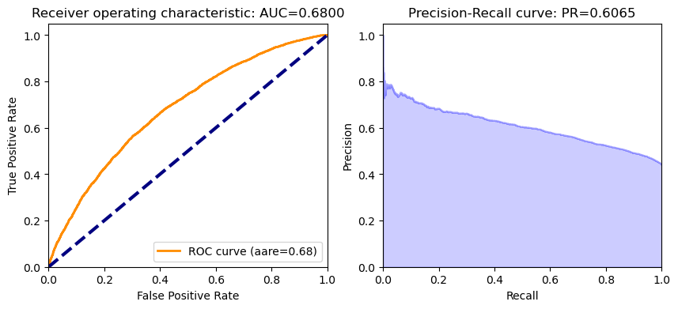

```python
# roc, auc curve, precision recall curve
ROC_AUC(RF_modl1,test_hex1,'loan_default')
```

- Lift is a measure of the effectiveness of a predictive model calculated as the ratio between the results obtained with and without the predictive model.
- from the graph we can see, we are 1.57 times more likely to capture a default as if we use no model.

```python
# create gains table
def createGains(model):
    predictions = model.predict(test_hex)
    test_scores = test_hex['loan_default'].cbind(predictions).as_data_frame()

    #sort on prediction (descending), add id, and decile for groups containing 1/10 of datapoints
    test_scores = test_scores.sort_values(by='predict',ascending=False)
    test_scores['row_id'] = range(0,0+len(test_scores))
    test_scores['decile'] = ( test_scores['row_id'] / (len(test_scores)/10) ).astype(int)
    #see count by decile
    test_scores.loc[test_scores['decile'] == 10]=9
    test_scores['decile'].value_counts()

    #create gains table
    gains = test_scores.groupby('decile')['loan_default'].agg(['count','sum'])
    gains.columns = ['count','actual']
    gains

    #add features to gains table
    gains['non_actual'] = gains['count'] - gains['actual']
    gains['cum_count'] = gains['count'].cumsum()
    gains['cum_actual'] = gains['actual'].cumsum()
    gains['cum_non_actual'] = gains['non_actual'].cumsum()
    gains['percent_cum_actual'] = (gains['cum_actual'] / np.max(gains['cum_actual'])).round(2)
    gains['percent_cum_non_actual'] = (gains['cum_non_actual'] / np.max(gains['cum_non_actual'])).round(2)
    gains['if_random'] = np.max(gains['cum_actual']) /10
    gains['if_random'] = gains['if_random'].cumsum()
    gains['lift'] = (gains['cum_actual'] / gains['if_random']).round(2)
    gains['K_S'] = np.abs( gains['percent_cum_actual'] -  gains['percent_cum_non_actual'] ) * 100
    gains['gain']=(gains['cum_actual']/gains['cum_count']*100).round(2)
    gains = pd.DataFrame(gains)
    return(gains)
createGains(RF_modl1)
```

```
drf prediction progress: |████████████████████████████████████████████████| 100%
```

| decile | count | actual | non_actual | cum_count | cum_actual | cum_non_actual | percent_cum_actual | percent_cum_non_actual | if_random | lift | K_S | gain |
| --- | --- | --- | --- | --- | --- | --- | --- | --- | --- | --- | --- | --- |
| 0 | 1420 | 981 | 439 | 1420 | 981 | 439 | 0.16 | 0.06 | 623.0 | 1.57 | 10.0 | 69.08 |
| 1 | 1420 | 897 | 523 | 2840 | 1878 | 962 | 0.30 | 0.12 | 1246.0 | 1.51 | 18.0 | 66.13 |
| 2 | 1419 | 781 | 638 | 4259 | 2659 | 1600 | 0.43 | 0.20 | 1869.0 | 1.42 | 23.0 | 62.43 |
| 3 | 1420 | 733 | 687 | 5679 | 3392 | 2287 | 0.54 | 0.29 | 2492.0 | 1.36 | 25.0 | 59.73 |
| 4 | 1419 | 642 | 777 | 7098 | 4034 | 3064 | 0.65 | 0.38 | 3115.0 | 1.30 | 27.0 | 56.83 |
| 5 | 1420 | 567 | 853 | 8518 | 4601 | 3917 | 0.74 | 0.49 | 3738.0 | 1.23 | 25.0 | 54.02 |
| 6 | 1420 | 531 | 889 | 9938 | 5132 | 4806 | 0.82 | 0.60 | 4361.0 | 1.18 | 22.0 | 51.64 |
| 7 | 1419 | 457 | 962 | 11357 | 5589 | 5768 | 0.90 | 0.72 | 4984.0 | 1.12 | 18.0 | 49.21 |
| 8 | 1420 | 403 | 1017 | 12777 | 5992 | 6785 | 0.96 | 0.85 | 5607.0 | 1.07 | 11.0 | 46.90 |
| 9 | 1419 | 238 | 1181 | 14196 | 6230 | 7966 | 1.00 | 1.00 | 6230.0 | 1.00 | 0.0 | 43.89 |

```python
# 27
createGains(RF_modl1)['K_S'].max()
```

```
drf prediction progress: |████████████████████████████████████████████████| 100%
```

```
27.0
```

## 5.2 RF model from Neighborhood Cleaning Rule under-sampling method

model evaluation

- roc, auc curve: 0.6849 (better performance than last model)
- area under precision recall curve: 0.0856 (much worse performance than last model)
- lift: 2.45 (better performance than last model)
- max K-S equals 26%. (slightly worse performance than last model)

```python
train_hex2, test_hex2, train2, test2 = hex_train_test_generator(X_rs_Neighbourhood, y_rs_Neighbourhood)
```

```
Parse progress: |█████████████████████████████████████████████████████████| 100%
Parse progress: |█████████████████████████████████████████████████████████| 100%
```

```
drf Model Build progress: |███████████████████████████████████████████████| 100%
drf prediction progress: |████████████████████████████████████████████████| 100%

   * ROC curve: The ROC curve plots the true positive rate vs. the false rositive sate

	  * The area under the curve (AUC): A value between 0.5 (random) and 1.0 (perfect), measuring the prediction accuracy

   * Recall (R) = The number of true positives / (the number of true positives + the number of false negatives)
```

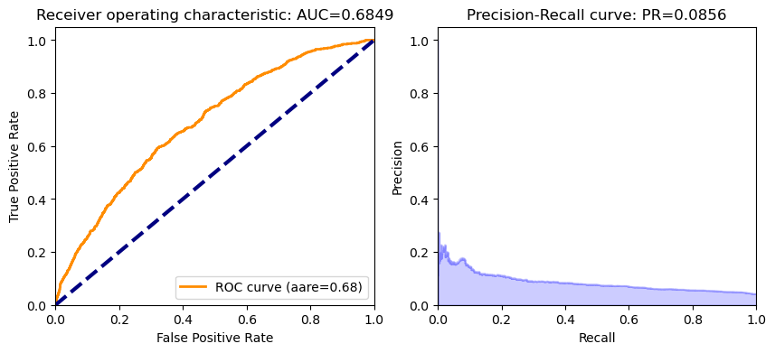

```python
# fit model
RF_modl2 = H2ORandomForestEstimator(
        model_id = 'RF',
        ntrees = 300,
        nfolds=10,
        min_rows=100,
        seed=1234)
RF_modl2.train(predictors,target,training_frame=train_hex2)
# roc, auc curve, precision recall curve
ROC_AUC(RF_modl2,test_hex2,'loan_default')
```

```python
createGains(RF_modl2)
```

```
drf prediction progress: |████████████████████████████████████████████████| 100%
```

| decile | count | actual | non_actual | cum_count | cum_actual | cum_non_actual | percent_cum_actual | percent_cum_non_actual | if_random | lift | K_S | gain |
| --- | --- | --- | --- | --- | --- | --- | --- | --- | --- | --- | --- | --- |
| 0 | 1457 | 142 | 1315 | 1457 | 142 | 1315 | 0.25 | 0.09 | 57.9 | 2.45 | 16.0 | 9.75 |
| 1 | 1457 | 98 | 1359 | 2914 | 240 | 2674 | 0.41 | 0.19 | 115.8 | 2.07 | 22.0 | 8.24 |
| 2 | 1457 | 76 | 1381 | 4371 | 316 | 4055 | 0.55 | 0.29 | 173.7 | 1.82 | 26.0 | 7.23 |
| 3 | 1457 | 61 | 1396 | 5828 | 377 | 5451 | 0.65 | 0.39 | 231.6 | 1.63 | 26.0 | 6.47 |
| 4 | 1456 | 54 | 1402 | 7284 | 431 | 6853 | 0.74 | 0.49 | 289.5 | 1.49 | 25.0 | 5.92 |
| 5 | 1457 | 47 | 1410 | 8741 | 478 | 8263 | 0.83 | 0.59 | 347.4 | 1.38 | 24.0 | 5.47 |
| 6 | 1457 | 38 | 1419 | 10198 | 516 | 9682 | 0.89 | 0.69 | 405.3 | 1.27 | 20.0 | 5.06 |
| 7 | 1457 | 37 | 1420 | 11655 | 553 | 11102 | 0.96 | 0.79 | 463.2 | 1.19 | 17.0 | 4.74 |
| 8 | 1457 | 15 | 1442 | 13112 | 568 | 12544 | 0.98 | 0.90 | 521.1 | 1.09 | 8.0 | 4.33 |
| 9 | 1456 | 11 | 1445 | 14568 | 579 | 13989 | 1.00 | 1.00 | 579.0 | 1.00 | 0.0 | 3.97 |

```python
createGains(RF_modl2)['K_S'].max()
```

```
drf prediction progress: |████████████████████████████████████████████████| 100%
```

```
26.000000000000007
```

## 5.3 RF model from RandomOverSampler method

- roc, auc curve: 0.6992 (better performance than model 2)
- area under precision recall curve: 0.5059 (better performance than model 2)
- lift: 1.85 (worse performance than model 2)
- max K-S equals 28.99%. (better performance than model 2)

```python
train_hex3, test_hex3, train3, test3 = hex_train_test_generator(X_rs_oversample, y_rs_oversample)
```

```
Parse progress: |█████████████████████████████████████████████████████████| 100%
Parse progress: |█████████████████████████████████████████████████████████| 100%
```

```
drf Model Build progress: |███████████████████████████████████████████████| 100%
drf prediction progress: |████████████████████████████████████████████████| 100%

   * ROC curve: The ROC curve plots the true positive rate vs. the false rositive sate

	  * The area under the curve (AUC): A value between 0.5 (random) and 1.0 (perfect), measuring the prediction accuracy

   * Recall (R) = The number of true positives / (the number of true positives + the number of false negatives)
```

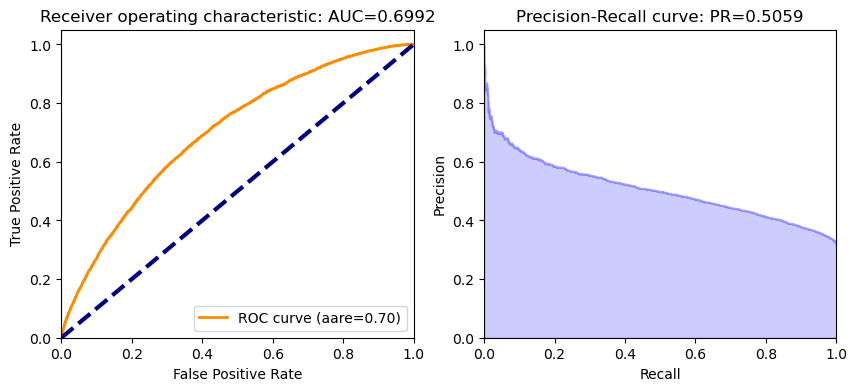

```python
# fit model
RF_modl.train(predictors,target,training_frame=train_hex3)
# roc, auc curve, precision recall curve
ROC_AUC(RF_modl,test_hex3,'loan_default')
```

```python
createGains(RF_modl)
```

```
drf prediction progress: |████████████████████████████████████████████████| 100%
```

| decile | count | actual | non_actual | cum_count | cum_actual | cum_non_actual | percent_cum_actual | percent_cum_non_actual | if_random | lift | K_S | gain |
| --- | --- | --- | --- | --- | --- | --- | --- | --- | --- | --- | --- | --- |
| 0 | 3781 | 2230 | 1551 | 3781 | 2230 | 1551 | 0.19 | 0.06 | 1204.8 | 1.85 | 13.0 | 58.98 |
| 1 | 3780 | 1866 | 1914 | 7561 | 4096 | 3465 | 0.34 | 0.13 | 2409.6 | 1.70 | 21.0 | 54.17 |
| 2 | 3781 | 1611 | 2170 | 11342 | 5707 | 5635 | 0.47 | 0.22 | 3614.4 | 1.58 | 25.0 | 50.32 |
| 3 | 3780 | 1454 | 2326 | 15122 | 7161 | 7961 | 0.59 | 0.31 | 4819.2 | 1.49 | 28.0 | 47.35 |
| 4 | 3781 | 1228 | 2553 | 18903 | 8389 | 10514 | 0.70 | 0.41 | 6024.0 | 1.39 | 29.0 | 44.38 |
| 5 | 3780 | 1082 | 2698 | 22683 | 9471 | 13212 | 0.79 | 0.51 | 7228.8 | 1.31 | 28.0 | 41.75 |
| 6 | 3781 | 891 | 2890 | 26464 | 10362 | 16102 | 0.86 | 0.63 | 8433.6 | 1.23 | 23.0 | 39.16 |
| 7 | 3780 | 785 | 2995 | 30244 | 11147 | 19097 | 0.93 | 0.74 | 9638.4 | 1.16 | 19.0 | 36.86 |
| 8 | 3781 | 596 | 3185 | 34025 | 11743 | 22282 | 0.97 | 0.87 | 10843.2 | 1.08 | 10.0 | 34.51 |
| 9 | 3780 | 305 | 3475 | 37805 | 12048 | 25757 | 1.00 | 1.00 | 12048.0 | 1.00 | 0.0 | 31.87 |

```python
createGains(RF_modl)['K_S'].max()
```

```
drf prediction progress: |████████████████████████████████████████████████| 100%
```

```
28.999999999999996
```

## 5.4 RF model from ADASYN over sampling

- roc, auc curve: 0.8285 (best performance)
- area under precision recall curve: 0.7792 (best performance)
- lift in first decile: 3.14 (best performance)
- max K-S equals 50. (best performance)

```python
# ADASYN
train_hex4, test_hex4, train4, test4 = hex_train_test_generator(X_rs_ADASYN, y_rs_ADASYN)
```

```
Parse progress: |█████████████████████████████████████████████████████████| 100%
Parse progress: |█████████████████████████████████████████████████████████| 100%
```

```
drf Model Build progress: |███████████████████████████████████████████████| 100%
drf prediction progress: |████████████████████████████████████████████████| 100%

   * ROC curve: The ROC curve plots the true positive rate vs. the false rositive sate

	  * The area under the curve (AUC): A value between 0.5 (random) and 1.0 (perfect), measuring the prediction accuracy

   * Recall (R) = The number of true positives / (the number of true positives + the number of false negatives)
```

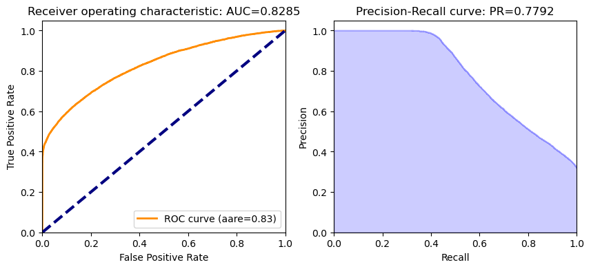

```python
# fit model
RF_modl.train(predictors,target,training_frame=train_hex4)

# roc, auc curve, precision recall curve
ROC_AUC(RF_modl,test_hex4,'loan_default')
```

```python
createGains(RF_modl)
```

```
drf prediction progress: |████████████████████████████████████████████████| 100%
```

| decile | count | actual | non_actual | cum_count | cum_actual | cum_non_actual | percent_cum_actual | percent_cum_non_actual | if_random | lift | K_S | gain |
| --- | --- | --- | --- | --- | --- | --- | --- | --- | --- | --- | --- | --- |
| 0 | 3786 | 3786 | 0 | 3786 | 3786 | 0 | 0.31 | 0.00 | 1204.4 | 3.14 | 31.0 | 100.00 |
| 1 | 3786 | 2509 | 1277 | 7572 | 6295 | 1277 | 0.52 | 0.05 | 2408.8 | 2.61 | 47.0 | 83.14 |
| 2 | 3786 | 1395 | 2391 | 11358 | 7690 | 3668 | 0.64 | 0.14 | 3613.2 | 2.13 | 50.0 | 67.71 |
| 3 | 3785 | 1089 | 2696 | 15143 | 8779 | 6364 | 0.73 | 0.25 | 4817.6 | 1.82 | 48.0 | 57.97 |
| 4 | 3786 | 873 | 2913 | 18929 | 9652 | 9277 | 0.80 | 0.36 | 6022.0 | 1.60 | 44.0 | 50.99 |
| 5 | 3786 | 735 | 3051 | 22715 | 10387 | 12328 | 0.86 | 0.48 | 7226.4 | 1.44 | 38.0 | 45.73 |
| 6 | 3785 | 587 | 3198 | 26500 | 10974 | 15526 | 0.91 | 0.60 | 8430.8 | 1.30 | 31.0 | 41.41 |
| 7 | 3786 | 480 | 3306 | 30286 | 11454 | 18832 | 0.95 | 0.73 | 9635.2 | 1.19 | 22.0 | 37.82 |
| 8 | 3786 | 371 | 3415 | 34072 | 11825 | 22247 | 0.98 | 0.86 | 10839.6 | 1.09 | 12.0 | 34.71 |
| 9 | 3785 | 219 | 3566 | 37857 | 12044 | 25813 | 1.00 | 1.00 | 12044.0 | 1.00 | 0.0 | 31.81 |

```python
createGains(RF_modl)['K_S'].max()
```

```
drf prediction progress: |████████████████████████████████████████████████| 100%
```

```
50.0
```

## Model performance summary

IF use random undersampling method

- roc, auc curve: 0.68
- area under precision recall curve: 0.6065
- lift: 1.57
- max K-S equals 27%.

IF use Neighborhood Cleaning Rule under-sampling method

- roc, auc curve: 0.6849
- area under precision recall curve: 0.0856
- lift: 2.45
- max K-S equals 26%.

IF use RandomOverSampler method

- roc, auc curve: 0.6992
- area under precision recall curve: 0.5059
- lift: 1.85
- max K-S equals 28.99%.

IF use ADASYN over sampling

- roc, auc curve: 0.8285 (best performance)
- area under precision recall curve: 0.7792 (best performance)
- lift in first decile: 3.14 (best performance)
- max K-S equals 50. (best performance)

Overall, ADASYN over sampling method has the best performance

## 6. Summary and busienss insights

**the most important predictors are**

The graph below shows variable importance, we can re-select features based on the result shown below, around 30 variables are more significant than the rest of variables

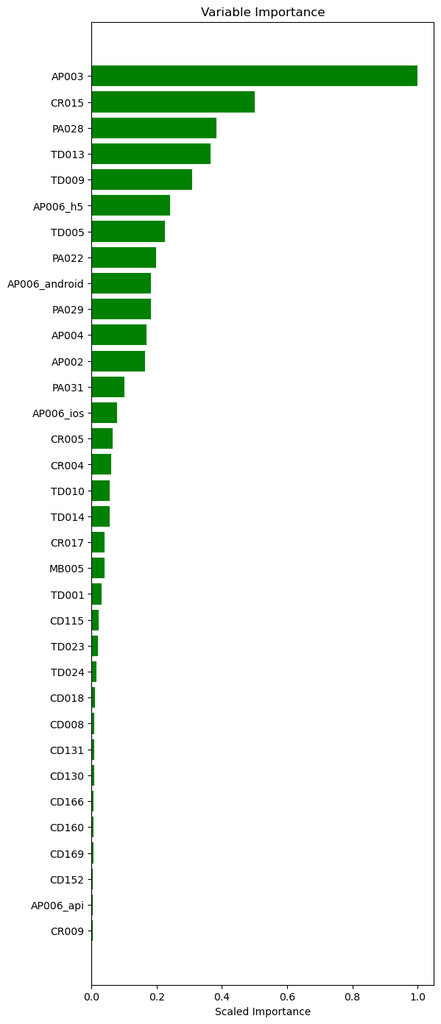

```python
# show variable importance, we will filter MB007, CD088 out
VarImp(RF_modl)
```

```python
# from the table below, you can see the top variables with most importance
Variable_Importances_table = RF_modl._model_json['output']['variable_importances']
Variable_Importances_table
```

```
Variable Importances:
```

|  | variable | relative_importance | scaled_importance | percentage |
| --- | --- | --- | --- | --- |
| 0 | AP003 | 170745.515625 | 1.000000 | 0.219616 |
| 1 | CR015 | 85359.570312 | 0.499923 | 0.109791 |
| 2 | PA028 | 65325.445312 | 0.382590 | 0.084023 |
| 3 | TD013 | 62150.828125 | 0.363997 | 0.079940 |
| 4 | TD009 | 52593.816406 | 0.308025 | 0.067647 |
| 5 | AP006_h5 | 41252.316406 | 0.241601 | 0.053060 |
| 6 | TD005 | 38437.367188 | 0.225115 | 0.049439 |
| 7 | PA022 | 33792.257812 | 0.197910 | 0.043464 |
| 8 | AP006_android | 31100.388672 | 0.182145 | 0.040002 |
| 9 | PA029 | 31067.750000 | 0.181954 | 0.039960 |
| 10 | AP004 | 28839.066406 | 0.168901 | 0.037093 |
| 11 | AP002 | 27844.500000 | 0.163076 | 0.035814 |
| 12 | PA031 | 17203.228516 | 0.100754 | 0.022127 |
| 13 | AP006_ios | 13326.167969 | 0.078047 | 0.017140 |
| 14 | CR005 | 10907.352539 | 0.063881 | 0.014029 |
| 15 | CR004 | 10362.912109 | 0.060692 | 0.013329 |
| 16 | TD010 | 9483.356445 | 0.055541 | 0.012198 |
| 17 | TD014 | 9431.834961 | 0.055239 | 0.012131 |
| 18 | CR017 | 6907.118164 | 0.040453 | 0.008884 |
| 19 | MB005 | 6729.815430 | 0.039414 | 0.008656 |

```
See the whole table with table.as_data_frame()
```

```python
# check columns descriptions
# the most important predictors are
# Top1: education level
# Top2: MONTH_CREDIT_CARD_MOB_MAX
# Top3: AVG_LEN_COLLECTION_OR_HIGH_RISK_CALLS
# Top4: TD_CNT_QUERY_LAST_6MON_P2P
# Top5: TD_CNT_QUERY_LAST_3MON_P2P
filtered_dictionary = Variables_Dictionary[Variables_Dictionary['var'].isin(Variable_Importances_table['variable'])]
filtered_dictionary.columns =  ['variable','description']
filtered_dictionary
```

|  | variable | description |
| --- | --- | --- |
| 4 | AP002 | CODE_GENDER |
| 5 | AP003 | CODE_EDUCATION |
| 6 | AP004 | LOAN_TERM |
| 15 | MB005 | YR_PHONE_ACTIVE |
| 20 | CR004 | CNT_QUERY_TIME_LAST_1MON |
| 21 | CR005 | CNT_QUERY_TIME_LAST_2MON |
| 25 | CR009 | AMT_LOAN_TOTAL |
| 31 | CR015 | MONTH_CREDIT_CARD_MOB_MAX |
| 33 | CR017 | SCORE_DEBIT_CARD_TOTAL_AMT |
| 38 | TD001 | TD_CNT_QUERY_LAST_7Day_P2P |
| 42 | TD005 | TD_CNT_QUERY_LAST_1MON_P2P |
| 46 | TD009 | TD_CNT_QUERY_LAST_3MON_P2P |
| 47 | TD010 | TD_CNT_QUERY_LAST_3MON_SMALL_LOAN |
| 50 | TD013 | TD_CNT_QUERY_LAST_6MON_P2P |
| 51 | TD014 | TD_CNT_QUERY_LAST_6MON_SMALL_LOAN |
| 61 | CD008 | LEN_TOTAL_INBOUND_CALLS_LAST_1MON |
| 71 | CD018 | CNT_TOTAL_OUTBOUND_CALLS_LAST_3MON |
| 168 | CD115 | CNT_DISTINCT_CALLS_LAST_1MON |
| 183 | CD130 | CNT_TOP3_FREQUENT_OUTBOUND_PHONE_NUMBERS_INBOUND_CALLS_LAST_2MON |
| 184 | CD131 | CNT_TOP3_FREQUENT_INBOUND_PHONE_NUMBERS_OUTBOUND_CALLS_LAST_2MON |
| 205 | CD152 | LEN_TOP3_FREQUENT_OUTBOUND_PHONE_NUMBERS_OUTBOUND_CALLS_LAST_3MON |
| 213 | CD160 | CNT_SERVICE_OUTBOUND_CALLS_LAST_2MON |
| 219 | CD166 | LEN_SERVICE_CALLS_LAST_1MON |
| 222 | CD169 | LEN_SERVICE_CALLS_LAST_2MON |
| 253 | PA022 | DAYS_BTW_APPLICATION_AND_FIRST_COLLECTION_OR_HIGH_RISK_CALL |
| 259 | PA028 | AVG_LEN_COLLECTION_OR_HIGH_RISK_CALLS |
| 260 | PA029 | AVG_LEN_COLLECTION_OR_HIGH_RISK_INBOUND_CALLS |
| 262 | PA031 | AVG_LEN_COLLECTION_CALLS |